# 10_18_2019_HW

John D.

October 14, 2019

```r
library(tidyverse)
library(rethinking)
options(mc.cores = parallel::detectCores())
rstan_options(auto_write = TRUE)
Sys.setenv(LOCAL_CPPFLAGS = '-march=native')
```

# 1. Consider the data(Wines2012) data table. These data are expert ratings of 20 different French and American wines by 9 different French and American judges. Your goal is to model *score*, the subjective rating assigned by each judge to each wine. I recommend standardizing.

In this first problem, consider only variation among judges and wines. Construct index vaiables of *judge* and *wine* and then use these index variables to construct a linear regression model. Justify your priors. You should end up with 9 judge parameters and 20 wine parameters. Use *ulam* instead of quap to build this model, and be sure to check the chains for convergence. If you’d rather build and model directly in Stan or PyMC3, go ahead. I just want you to use Hamiltonian Monte Carlo instead of quadratic approximation.

How do you interprest the variation among individual judges and invidual wines? Do you notice any patterns, just by plotting differences? Which judges gave the highest/lowest ratings? Which wines were rated worst/best on average?

```r
#?Wines2012
data("Wines2012")
dat <- Wines2012
head(dat)
```

```
##             judge flight wine score wine.amer judge.amer
## 1 Jean-M Cardebat  white   A1    10         1          0
## 2 Jean-M Cardebat  white   B1    13         1          0
## 3 Jean-M Cardebat  white   C1    14         0          0
## 4 Jean-M Cardebat  white   D1    15         0          0
## 5 Jean-M Cardebat  white   E1     8         1          0
## 6 Jean-M Cardebat  white   F1    13         1          0
```

```r
summary(dat)
```

```
##              judge      flight        wine         score
##  Daniele Meulder:20   red  :90   A1     :  9   Min.   : 7.0
##  Francis Schott :20   white:90   A2     :  9   1st Qu.:12.0
##  Jamal Rayyis   :20              B1     :  9   Median :14.5
##  Jean-M Cardebat:20              B2     :  9   Mean   :14.2
##  John Foy       :20              C1     :  9   3rd Qu.:16.0
##  Linda Murphy   :20              C2     :  9   Max.   :19.5
##  (Other)        :60              (Other):126
##    wine.amer     judge.amer
##  Min.   :0.0   Min.   :0.0000
##  1st Qu.:0.0   1st Qu.:0.0000
##  Median :1.0   Median :1.0000
##  Mean   :0.6   Mean   :0.5556
##  3rd Qu.:1.0   3rd Qu.:1.0000
##  Max.   :1.0   Max.   :1.0000
##
```

```r
dat_slim <- list(
  j = as.integer(as.factor(dat$judge)),
  w = as.integer(as.factor((dat$wine))),
  score_std = (dat$score - mean(dat$score)) / sd(dat$score)
)

model_1 <- ulam(
  alist(
    score_std ~ dnorm(mu, sigma),
    mu <- judge[j] + wine[w],
    judge[j] ~ dnorm(0, 0.25),
    wine[w] ~ dnorm(0, 0.25),
    sigma ~ dexp(1)
  ),
  data = dat_slim, chains = 4, iter = 10000, cores = 4, log_lik = T
)

precis(model_1, depth = 2)
```

```
##                  mean         sd        5.5%        94.5%    n_eff
## judge[1] -0.200548902 0.15679937 -0.44880892  0.050737714 32128.29
## judge[2]  0.151800397 0.15512725 -0.09380915  0.401951424 31613.85
## judge[3]  0.147678836 0.15850429 -0.10611100  0.400149309 33010.56
## judge[4] -0.386012263 0.15885799 -0.63896157 -0.132269785 34502.23
## judge[5]  0.569599125 0.15887655  0.31349325  0.820582390 30366.46
## judge[6]  0.341108487 0.15509613  0.09343508  0.589875700 31798.34
## judge[7]  0.094329949 0.15568959 -0.15539955  0.344555397 33588.02
## judge[8] -0.469650258 0.15808597 -0.72275171 -0.214441586 33415.51
## judge[9] -0.246007793 0.15551322 -0.49503351  0.003667288 33080.46
## wine[1]   0.066818076 0.18917609 -0.23427589  0.372417057 33682.28
## wine[2]   0.047740185 0.19206288 -0.26193295  0.355580897 34126.34
## wine[3]   0.127446010 0.18902930 -0.17395271  0.430488060 36564.22
## wine[4]   0.263964254 0.19254002 -0.04385159  0.571386324 31528.14
## wine[5]  -0.058147869 0.19408425 -0.36783859  0.251261741 38612.81
## wine[6]  -0.175258689 0.18686696 -0.47626506  0.120981640 35148.74
## wine[7]   0.138064525 0.18861835 -0.16085731  0.443342832 36846.16
## wine[8]   0.128477566 0.19119265 -0.17695296  0.434146207 34481.43
## wine[9]   0.039528382 0.18955492 -0.26444973  0.339742348 37752.48
## wine[10]  0.058589309 0.19232041 -0.24693043  0.363931577 33885.59
## wine[11] -0.004601566 0.19277339 -0.31015293  0.302576516 34539.51
## wine[12] -0.015977468 0.19233869 -0.32453902  0.292348468 36429.09
## wine[13] -0.049982304 0.18688542 -0.34561421  0.253429694 37359.27
## wine[14]  0.004521562 0.18895798 -0.29450068  0.305424231 33169.37
## wine[15] -0.101567876 0.19222207 -0.40605706  0.202337745 36380.64
## wine[16] -0.094331271 0.18990640 -0.40052628  0.211468748 34055.81
## wine[17] -0.068038657 0.18867852 -0.37142131  0.232883513 32928.70
## wine[18] -0.409730997 0.19149310 -0.71366518 -0.102859749 35290.25
## wine[19] -0.076297572 0.19276456 -0.38809093  0.230112627 38878.01
## wine[20]  0.183874163 0.19292818 -0.12632869  0.491637963 36566.06
## sigma     0.865924084 0.04991129  0.79029212  0.948966080 28366.88
##               Rhat
## judge[1] 0.9998855
## judge[2] 0.9999047
## judge[3] 0.9998290
## judge[4] 0.9998714
## judge[5] 0.9998978
## judge[6] 1.0000625
## judge[7] 1.0001046
## judge[8] 0.9999082
## judge[9] 0.9998752
## wine[1]  0.9999825
## wine[2]  0.9999156
## wine[3]  0.9998681
## wine[4]  0.9998411
## wine[5]  0.9998513
## wine[6]  0.9999954
## wine[7]  0.9998483
## wine[8]  0.9999135
## wine[9]  0.9999741
## wine[10] 0.9998521
## wine[11] 0.9999117
## wine[12] 1.0000891
## wine[13] 0.9998523
## wine[14] 0.9998557
## wine[15] 0.9999086
## wine[16] 0.9999474
## wine[17] 0.9998807
## wine[18] 0.9999269
## wine[19] 0.9998509
## wine[20] 0.9999449
## sigma    0.9998380
```

```
## Waiting to draw page 2 of 2
```

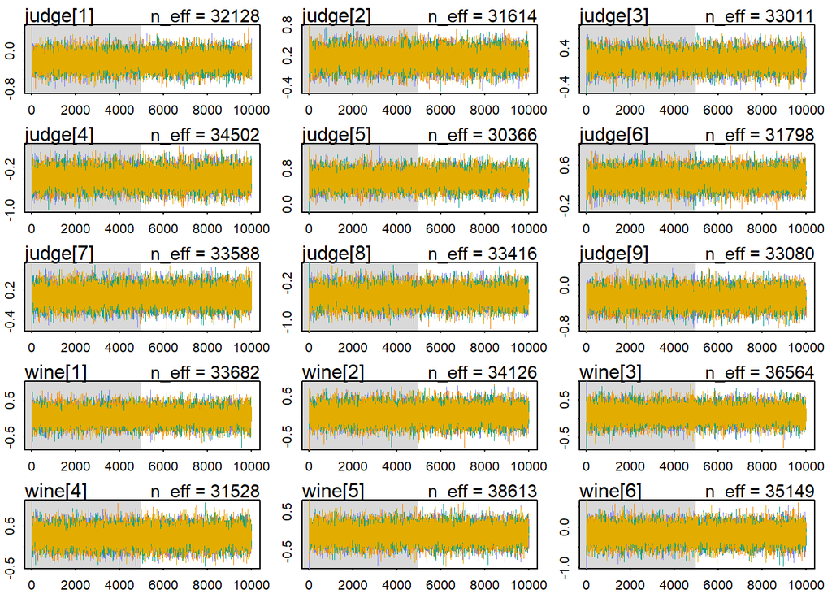

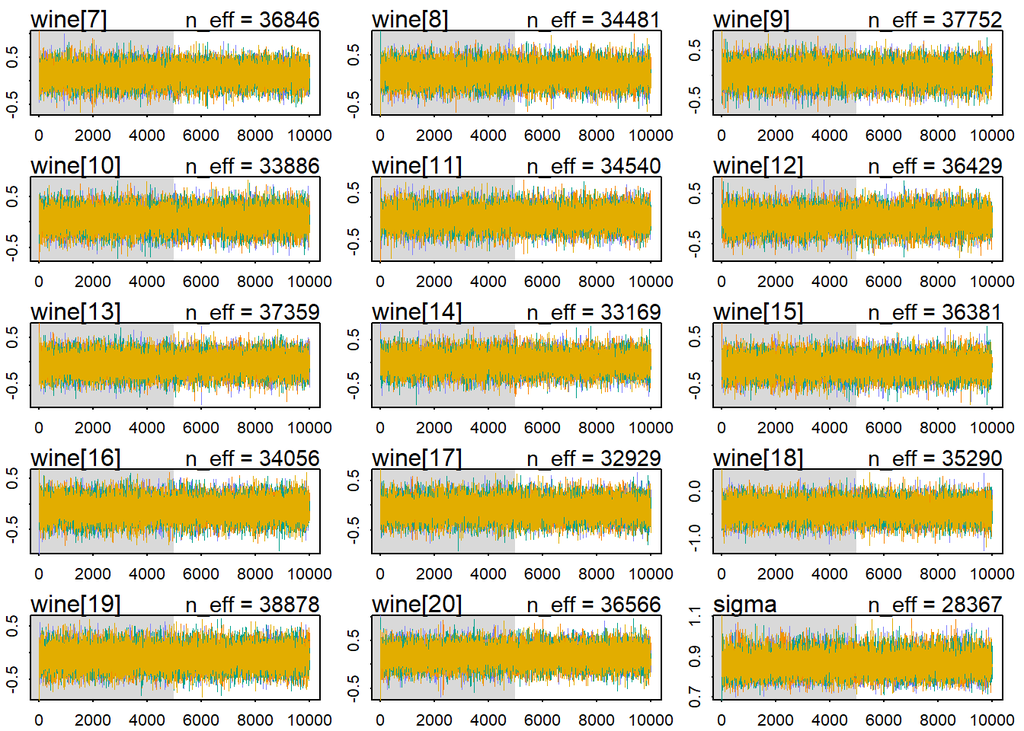

```r
traceplot(model_1)
```

```
## Waiting to draw page 2 of 2
```

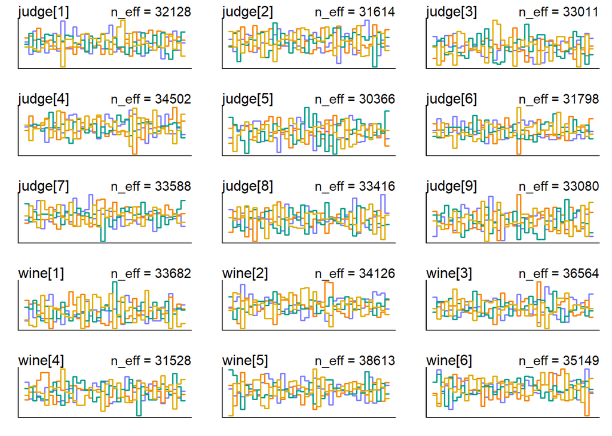

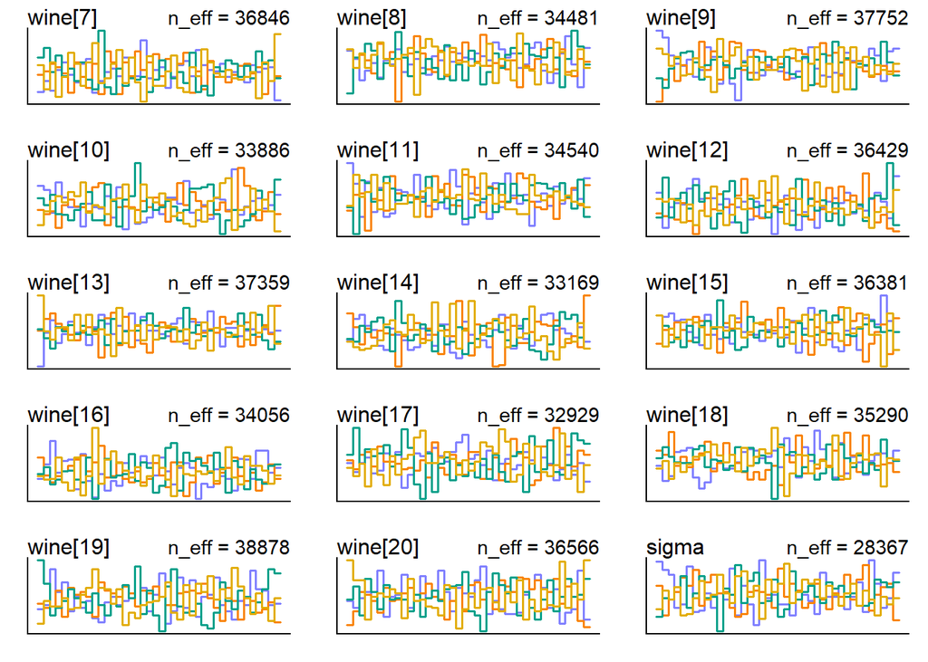

```r
trankplot(model_1)
```

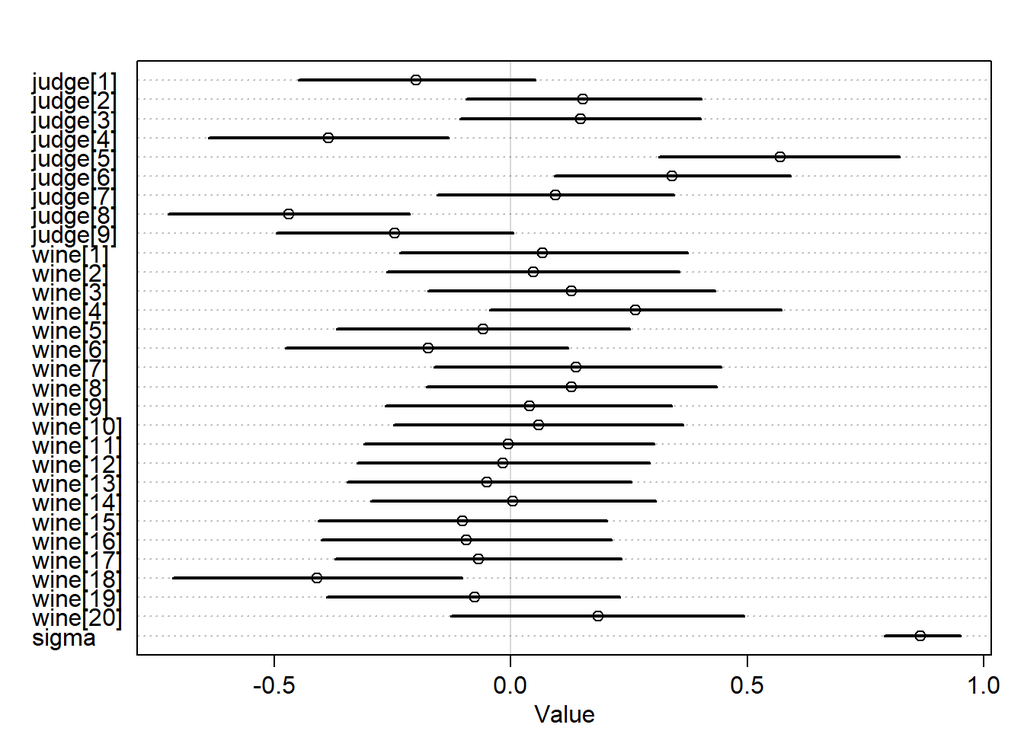

```r
par(mfrow = c(1,1))
plot(precis(model_1, depth = 2))
```

The judges clearly vary with some always giving bad, some always giving average, and some always giving good scores. The wines were all pretty much centered around uniforms except wine 18 which received bad scores.

# 2. Now consider three features of the wines and judges:

1. `flight`: Whether the wine is red or white
2. `wine.amer`: Indicator variable for American wines
3. `judge.amer`: Indictor variable for American judges

Use the indicator or index variables to model the influence of these features on the scores. Omit the individual judges and wine index variables from Problem 1. Do not include interaction effects yet. Again use `ulam`, justify your priors, and be sure to check the chains. What do you conclude about the differences among the wines and judges? Try to relate the results to the inferences in Problem 1.